# How borrower's details affects on the number of delinquent days

## by Ban Choon Chua

## Investigation Overview

I wanted to show, how the borrower's details affects on the number of delinquent days

## Dataset Overview

The dataset consist of 113937 entries with 81 columns. The attributes that were used for this presentation are Credit Score, Prosper Score, Employment, Type of Loan, Borrower rates, Income, LoanCurrentDaysDelinquent. A total of 751 entries were removed from the analysis due to inconsistencies or missing information.

## Number of applicant's borrower rate

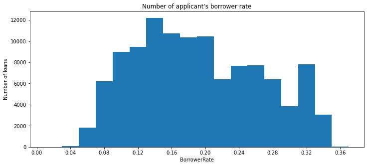

## Number of applicant's Credit Score

We can see that majority of the borrower has a credit score of 700 +/- 50

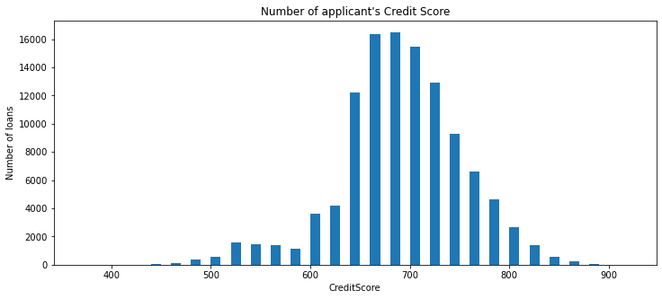

## Pairwise Correlations

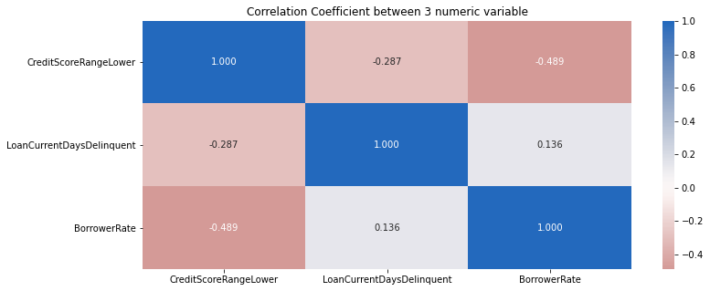

## Scatterplot of Credit Score vs Number of Delinquent Days

The scatter plot shows that the higher the borrower's credit score the lower the borrower rate as shown the darker blue at the top indicating low rates and yellow/green at the bottom indicating higher rates of which we expected. However, regardless of the credit score, the days of delinquent are spread out from 0 to 2500 days. Showing us that high credit score with low borrowing rate does not mean lower number of delinquent days

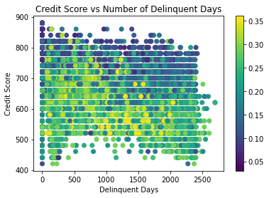